# Moderate Food Poverty: A Global Challenge

```
"Food is a basic right, not a privilege."
```

Author: **Sachdev Sajith**

Published: **April 23, 2025**

UNICEF is committed to promoting and protecting the rights of children in India, where it has been active for 75 years. With approximately 450 staff members working in 17 states, covering 90 per cent of India’s child population, UNICEF has the largest field presence among UN agencies in the country. This enables UNICEF to effectively reach the most vulnerable children.

[EXPLORE UNICEF](https://www.unicef.org/india/what-we-do)

|

[JOIN UNICEF](https://www.unicef.org/india/take-action)

|

[DONATE](https://cloud.info.unicef.org/donate?)

## Understanding Moderate Food Poverty

Food poverty remains one of the most pressing global challenges, affecting millions of lives across all age groups. Among the most vulnerable are young children, whose well-being and development are directly impacted by limited access to food and basic services. Understanding how poverty affects children, especially in their early years is crucial for shaping effective policies and interventions. Child food poverty harms all children, but it is particularly damaging in early childhood when insufficient dietary intake of essential nutrients can cause the greatest harm to child survival, physical growth and cognitive development. The consequences can last a lifetime: children deprived of good nutrition in early childhood do less well at school and have lower earning capacity in adulthood, trapping them and their families in a cycle of poverty and deprivation.

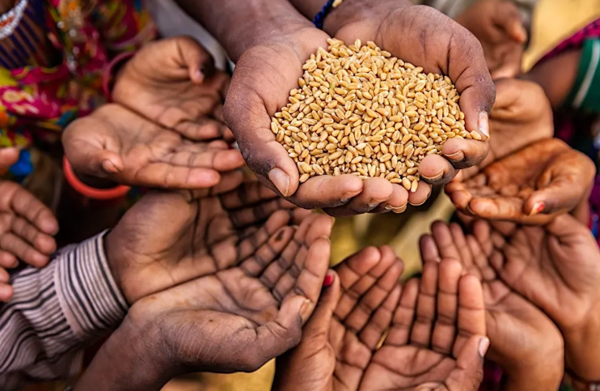

## Data Preparation

The dataset used in this report originates from UNICEF’s global monitoring efforts and contains annual records of moderate poverty rates for a wide range of countries. This analysis takes a closer look at children aged 6 to 23 months, examining patterns in poverty and exploring even small differences to better identify where support is needed most, ensuring that no child is left behind. This report draws on UNICEF data to provide a comprehensive analysis of moderate poverty across countries and over time. Using Python and the Plotnine visualization library, we examine where poverty is most prevalent, how it changes over time, and how it correlates with key economic indicators. Our goal is to highlight global patterns, regional disparities, and areas where progress is urgently needed to ensure more equitable development.

Please find the Tableau Version of this Report: [Tableau Public – Moderate Poverty Dashboard](https://public.tableau.com/app/profile/sachdev.sajith/viz/SachdevSajith/Dashboard1)

```python
import pandas as pd
import geopandas as gpd
from plotnine import *

# Reading the CSV file data
df = pd.read_csv("merged_unicef_data.csv")

# Renaming column for plotting ease
df = df.rename(columns={
    "GDP per capita (constant 2015 US$)": "GDP",
    "Life expectancy at birth, total (years)": "life_expectancy"
})

# Loading world shapefile
world = gpd.read_file("ne_110m_admin_0_countries.shp")
world = world.rename(columns={"NAME": "country", "CONTINENT": "continent"})
```

## Continental Breakdown of Moderate Food Poverty

This visualization illustrates the average moderate poverty rate across continents, based on the share of populations living under the threshold for a healthy diet.

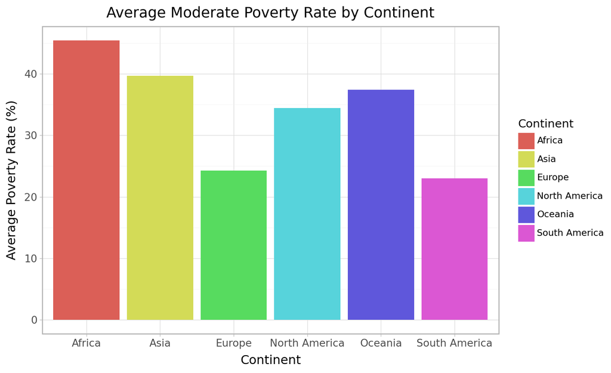

```python
# Merging continent information
df_continent = df.merge(world[['country', 'continent']], on="country", how="left")

# Calculating average poverty by continent
continent_avg = (
    df_continent
    .dropna(subset=["obs_value", "continent"])
    .groupby("continent")["obs_value"]
    .mean()
    .reset_index()
    .sort_values("obs_value", ascending=False)
)

# Plotting
(
    ggplot(continent_avg) +
    aes(x="continent", y="obs_value", fill="continent") +
    geom_col() +
    labs(
        title="Average Moderate Poverty Rate by Continent",
        x="Continent",
        y="Average Poverty Rate (%)",
        fill="Continent"
    ) +
    theme_light() +
    theme(
        figure_size=(8.2, 5),
        axis_title=element_text(size=12),
        axis_text=element_text(size=10),
        plot_title=element_text(size=14)
    )
)
```

### Key Insights from the Bar Chart

- **Africa** leads with the highest average poverty rate, exceeding 45%, reflecting deep systemic challenges in access to affordable, nutritious food.
- **Asia** follows closely at around 40%, particularly driven by countries in South and Southeast Asia.
- **Europe** and **South America** report the lowest average rates, under 25%, highlighting better food security frameworks and support systems.
- **North America** and **Oceania** fall in the mid-range, suggesting pockets of inequality within otherwise high-income regions.

These findings underscore the **geographic dimension of food poverty** and the urgent need for region-specific strategies.Interventions must consider local economies, social protections, and agricultural systems to ensure every child and family has the right to a healthy diet.

## A Global Snapshot of Moderate Food Poverty

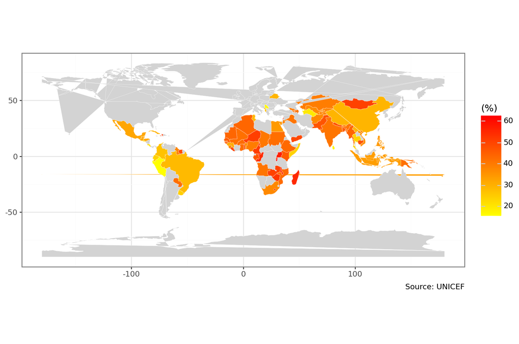

```python
# Average food poverty by country
country_avg = (
    df.groupby('country', as_index=False)['obs_value']
    .mean()
    .rename(columns={'obs_value': 'avg_poverty'})
)

# Merging with world map
map_data = world.merge(country_avg, on="country", how="left")

# Extracting the map coordinates
map_data = map_data.explode(index_parts=False)
map_data["coords"] = map_data.geometry.apply(
    lambda geom: list(geom.exterior.coords) if geom and hasattr(geom, "exterior") else []
)
map_long = map_data.explode("coords")
map_long[["long", "lat"]] = pd.DataFrame(map_long["coords"].tolist(), index=map_long.index)

# Plotting
(
    ggplot(map_long, aes(x='long', y='lat', group='country', fill='avg_poverty')) +
    geom_polygon(color='white', size=0.1) +
    scale_fill_gradient(low="yellow", high="red", na_value="lightgrey", name="(%)") +
    labs(caption="Source: UNICEF", x="", y="") +
    coord_fixed() +
    theme_bw() +
    theme(figure_size=(8.3, 5.5))
)
```

## A Statistical Portrait of Poverty and Life Expectancy

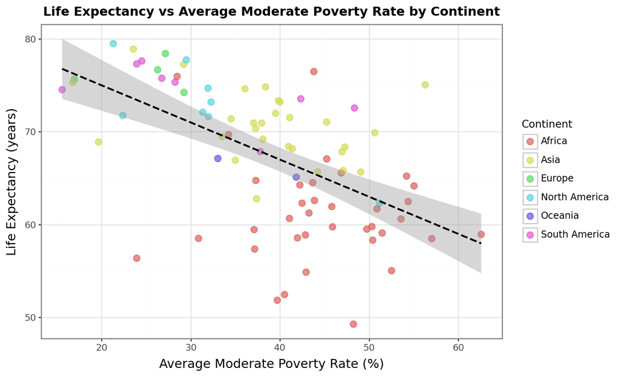

```python
# Merging continent information
df_continent = df.merge(world[['country', 'continent']], on="country", how="left")

# Summarizing data
summary = (
    df_continent
    .dropna(subset=["obs_value", "life_expectancy"])
    .groupby(["country", "continent"], as_index=False)
    .agg({
        "obs_value": "mean",
        "life_expectancy": "mean"
    })
)

# Plotting
(
    ggplot(summary, aes(x="obs_value", y="life_expectancy", color="continent")) +
    geom_point(size=3, alpha=0.7) +
    geom_smooth(method='lm', color='black', linetype='dashed') +
    labs(
        title="Life Expectancy vs Average Moderate Poverty Rate by Continent",
        x="Average Moderate Poverty Rate (%)",
        y="Life Expectancy (years)",
        color="Continent"
    ) +
    theme_bw() +
    theme(
        figure_size=(8.2, 5),
        plot_title=element_text(size=12, weight="bold"),
        axis_title=element_text(size=12),
        legend_title=element_text(size=10),
        legend_text=element_text(size=9)
    )
)
```

### Tracking Life Expectancy Dynamics Across Continents

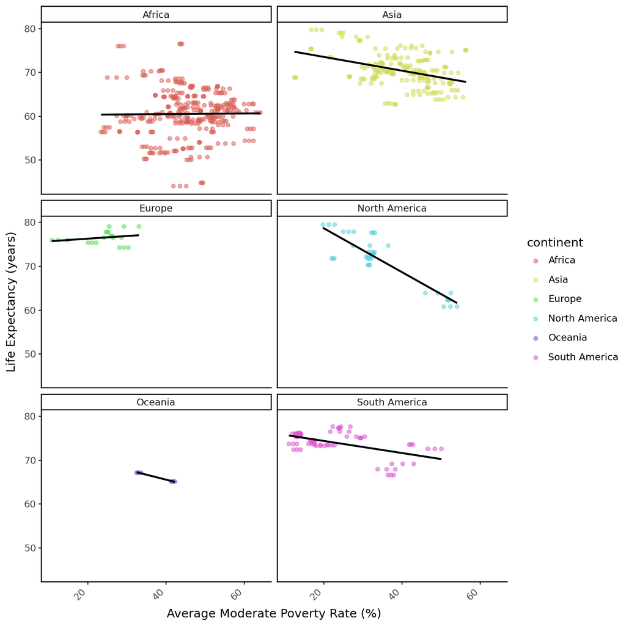

```python
# Reading continent information
world = gpd.read_file("ne_110m_admin_0_countries.shp")[["NAME", "CONTINENT"]]
world.columns = ["country", "continent"]

# Merging dataset with continent information
df_with_continent = df.merge(world, on="country", how="left")

# Filtering out the missing values
df_with_continent = df_with_continent.dropna(subset=["obs_value", "continent", "country", "life_expectancy"])

# Plotting Facets by continent with regression line
(
    ggplot(df_with_continent) +
    aes(x="obs_value", y="life_expectancy", color="continent") +
    geom_point(alpha=0.5) +
    geom_smooth(method='lm', se=False, color='black') +
    facet_wrap("continent", nrow=3) +
    labs(
        x="Average Moderate Poverty Rate (%)",
        y="Life Expectancy (years)"
    ) +
    theme_classic() +
    theme(
        figure_size=(8, 8),
        plot_title=element_text(size=13.8, weight='bold'),
        axis_text_x=element_text(rotation=45, hjust=1)
    )
)
```